# Problem Set #1: Time Series Analysis

## Forecasting and Time Series — Emory University

**Instructor**: Elena Pesavento **Data**: Bitcoin (BTC-USD) Daily Returns, Jan 2016 – Feb 2026 **Source**: Yahoo Finance via `yfinance`

## Setup and Imports

```python
import pandas as pd
import numpy as np
import matplotlib.pyplot as plt
import seaborn as sns
from scipy import stats
from statsmodels.tsa.stattools import acf, pacf
from statsmodels.graphics.tsaplots import plot_acf, plot_pacf
from statsmodels.stats.diagnostic import acorr_ljungbox
import warnings
warnings.filterwarnings('ignore')

# Plotting configuration
plt.style.use('seaborn-v0_8-darkgrid')
sns.set_palette("husl")
plt.rcParams['figure.dpi'] = 150
plt.rcParams['savefig.dpi'] = 300
np.random.seed(42)

print("Setup complete.")
```

```
Setup complete.
```

## Problem 1

> **Why would you be surprised if I told you that $y_t$ was MA(1) but that $\text{corr}(y_t, y_{t-1}) = 0.7$?**

### Approach

For an MA(1) process $y_t = \varepsilon_t + \theta\,\varepsilon_{t-1}$ with $\varepsilon_t \sim WN(0,\sigma^2)$, the first-order autocorrelation is:

$$\rho_1 = \frac{\theta}{1 + \theta^2}$$

We need to determine whether $|\rho_1| = 0.7$ is achievable for any value of $\theta$.

```
MA(1) Feasibility Analysis
=======================================================
  MA(1) autocorrelation:  rho_1 = theta / (1 + theta^2)
  Maximum |rho_1|:        0.5  (at theta = +/-1)
  Observed rho_1:         0.7
  Feasible for MA(1)?     No
=======================================================
```

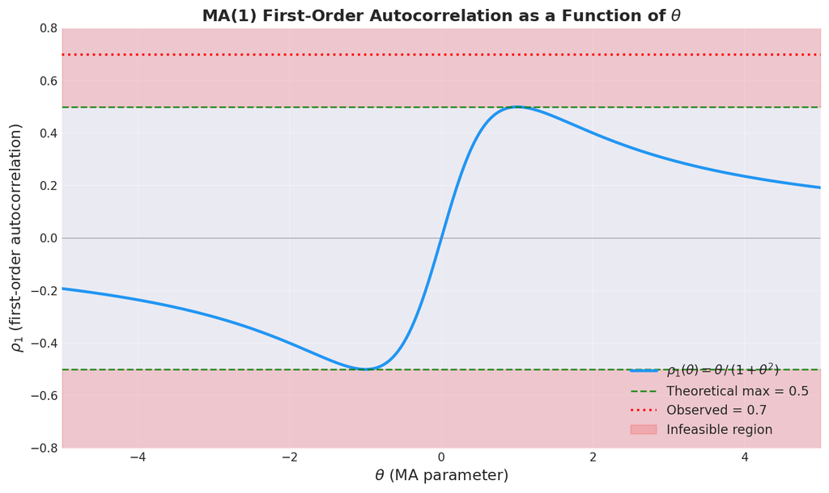

```
Figure saved: outputs/figures/ma1_theoretical_bounds.png
```

```python
# ── Problem 1: MA(1) Theoretical Bounds ──────────────────────────────────

# For MA(1): rho_1 = theta / (1 + theta^2)
# Find the maximum by taking derivative and setting to zero:
#   d(rho_1)/d(theta) = (1 - theta^2) / (1 + theta^2)^2 = 0
#   => theta = ±1, giving rho_1 = ±0.5

theta_range = np.linspace(-5, 5, 2000)
rho_values = theta_range / (1 + theta_range**2)

max_rho = 0.5  # theoretical maximum
observed_rho = 0.7

print("MA(1) Feasibility Analysis")
print("=" * 55)
print(f"  MA(1) autocorrelation:  rho_1 = theta / (1 + theta^2)")
print(f"  Maximum |rho_1|:        0.5  (at theta = +/-1)")
print(f"  Observed rho_1:         {observed_rho}")
print(f"  Feasible for MA(1)?     {'Yes' if abs(observed_rho) <= max_rho else 'No'}")
print("=" * 55)

# ── Visualization ────────────────────────────────────────────────────────
fig, ax = plt.subplots(figsize=(10, 6))

ax.plot(theta_range, rho_values, linewidth=2.5, color='#2196F3',
        label=r'$\rho_1(\theta) = \theta\,/\,(1+\theta^2)$')
ax.axhline(y=max_rho, color='green', linestyle='--', linewidth=1.5,
           alpha=0.8, label=f'Theoretical max = {max_rho}')
ax.axhline(y=-max_rho, color='green', linestyle='--', linewidth=1.5, alpha=0.8)
ax.axhline(y=observed_rho, color='red', linestyle=':', linewidth=2,
           alpha=0.9, label=f'Observed = {observed_rho}')
ax.axhline(y=0, color='gray', linewidth=0.5)

# Shade the infeasible region
ax.fill_between(theta_range, max_rho, 1, alpha=0.15, color='red', label='Infeasible region')
ax.fill_between(theta_range, -1, -max_rho, alpha=0.15, color='red')

ax.set_xlabel(r'$\theta$ (MA parameter)', fontsize=13)
ax.set_ylabel(r'$\rho_1$ (first-order autocorrelation)', fontsize=13)
ax.set_title('MA(1) First-Order Autocorrelation as a Function of $\\theta$',
             fontsize=14, fontweight='bold')
ax.set_ylim(-0.8, 0.8)
ax.set_xlim(-5, 5)
ax.legend(fontsize=11, loc='lower right')
ax.grid(True, alpha=0.3)

plt.tight_layout()
plt.savefig('outputs/figures/ma1_theoretical_bounds.png', dpi=300, bbox_inches='tight')
plt.show()
print("Figure saved: outputs/figures/ma1_theoretical_bounds.png")
```

### Discussion — Problem 1

**Finding:** An autocorrelation of $\rho_1 = 0.7$ is **impossible** for any MA(1) process.

**Why this is surprising:**

1. **Theoretical bound.** For MA(1), $\rho_1 = \theta/(1+\theta^2)$. Maximizing over $\theta$ (by calculus or AM-GM inequality) gives $|\rho_1| \le 0.5$, with equality at $\theta = \pm 1$. Since $0.7 > 0.5$, no real $\theta$ can produce this correlation.
2. **Intuition.** An MA(1) process has "memory" of only one shock. That limited memory caps how correlated consecutive observations can be. A correlation as high as 0.7 implies persistence that one lagged shock alone cannot generate.
3. **What the data might actually be.** A first-order autocorrelation of 0.7 is more consistent with:
   - An **AR(1)** process with $\phi \approx 0.7$
   - An **ARMA(1,1)** or higher-order MA/ARMA model
   - A near-unit-root or non-stationary process

## Problem 2

> **If $x_t$ and $y_t$ are each white noise, is $x_t + y_t$ white noise? Is this true in general?**

### Approach

We prove the result analytically and verify with simulation. Recall that $z_t$ is white noise if $E[z_t]=0$, $\text{Var}(z_t)=\sigma_z^2 < \infty$ (constant), and $\text{Cov}(z_t, z_s)=0$ for $t \neq s$.

```
Sum of White Noise — Ljung-Box Tests (lag 20)
============================================================
Case 1 (independent):  p-value = 0.5994  →  White noise
Case 2 (dependent):    p-value = 0.0000  →  NOT white noise
============================================================
```

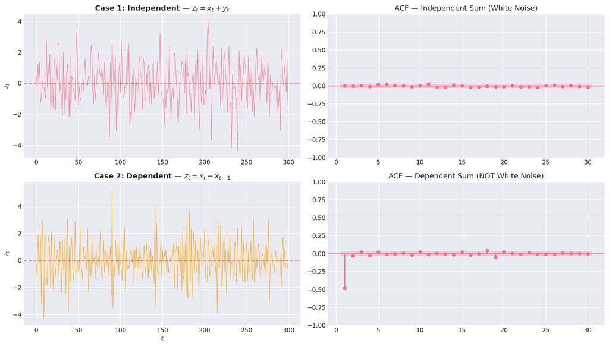

```
Figure saved: outputs/figures/white_noise_sum.png
```

```python
# ── Problem 2: Sum of White Noise Processes ───────────────────────────────

n = 5000
rng = np.random.default_rng(123)  # local RNG for reproducible demo

# ── Case 1: Independent white noise ──────────────────────────────────────
x1 = rng.normal(0, 1, n)
y1 = rng.normal(0, 1, n)
z1 = x1 + y1  # sum of independent WN

lb1 = acorr_ljungbox(z1, lags=20, return_df=True)

# ── Case 2: Dependent white noise ────────────────────────────────────────
# y2_t = -x_{t-1} is marginally WN(0,1) but cross-correlated with x at lag 1
x2 = rng.normal(0, 1, n)
y2 = np.empty(n)
y2[0] = rng.normal(0, 1)
y2[1:] = -x2[:-1]       # y2_t = -x_{t-1}, still WN marginally
z2 = x2 + y2             # z_t = x_t - x_{t-1} → MA(1)-like, NOT white noise

lb2 = acorr_ljungbox(z2, lags=20, return_df=True)

print("Sum of White Noise — Ljung-Box Tests (lag 20)")
print("=" * 60)
print(f"Case 1 (independent):  p-value = {lb1['lb_pvalue'].iloc[-1]:.4f}"
      f"  →  {'White noise' if lb1['lb_pvalue'].iloc[-1] > 0.05 else 'NOT white noise'}")
print(f"Case 2 (dependent):    p-value = {lb2['lb_pvalue'].iloc[-1]:.4f}"
      f"  →  {'White noise' if lb2['lb_pvalue'].iloc[-1] > 0.05 else 'NOT white noise'}")
print("=" * 60)

# ── Visualization ────────────────────────────────────────────────────────
fig, axes = plt.subplots(2, 2, figsize=(14, 8))

# Case 1 time series
axes[0, 0].plot(z1[:300], linewidth=0.7, alpha=0.8)
axes[0, 0].set_title('Case 1: Independent — $z_t = x_t + y_t$', fontweight='bold')
axes[0, 0].set_ylabel('$z_t$')
axes[0, 0].axhline(0, color='red', linestyle='--', alpha=0.4)

# Case 1 ACF
plot_acf(z1, lags=30, ax=axes[0, 1], zero=False,
         title='ACF — Independent Sum (White Noise)')

# Case 2 time series
axes[1, 0].plot(z2[:300], linewidth=0.7, alpha=0.8, color='orange')
axes[1, 0].set_title('Case 2: Dependent — $z_t = x_t - x_{t-1}$', fontweight='bold')
axes[1, 0].set_ylabel('$z_t$')
axes[1, 0].set_xlabel('$t$')
axes[1, 0].axhline(0, color='red', linestyle='--', alpha=0.4)

# Case 2 ACF
plot_acf(z2, lags=30, ax=axes[1, 1], zero=False,
         title='ACF — Dependent Sum (NOT White Noise)')

plt.tight_layout()
plt.savefig('outputs/figures/white_noise_sum.png', dpi=300, bbox_inches='tight')
plt.show()
print("Figure saved: outputs/figures/white_noise_sum.png")
```

### Discussion — Problem 2

**Answer:** If $x_t$ and $y_t$ are **independent** white noise processes, then $z_t = x_t + y_t$ **is** white noise. This is **not** true in general when $x_t$ and $y_t$ are dependent.

**Proof (independent case):**

Let $z_t = x_t + y_t$ where $x_t \sim WN(0, \sigma_x^2)$ and $y_t \sim WN(0, \sigma_y^2)$ are independent.

1. $E[z_t] = E[x_t] + E[y_t] = 0$
2. $\text{Var}(z_t) = \sigma_x^2 + \sigma_y^2$ (constant, by independence)
3. For $t \neq s$: $$\text{Cov}(z_t, z_s) = \text{Cov}(x_t, x_s) + \text{Cov}(x_t, y_s) + \text{Cov}(y_t, x_s) + \text{Cov}(y_t, y_s) = 0$$

All four covariances are zero: the first and last by the WN property, the cross-terms by independence. So $z_t \sim WN(0, \sigma_x^2 + \sigma_y^2)$.

**Counterexample (dependent case):**

Let $x_t \sim WN(0,1)$ and set $y_t = -x_{t-1}$. Then $y_t$ is also $WN(0,1)$ (marginally), but $z_t = x_t + y_t = x_t - x_{t-1}$ has: $$\text{Cov}(z_t, z_{t-1}) = \text{Cov}(x_t - x_{t-1},\, x_{t-1} - x_{t-2}) = -\sigma_x^2 \neq 0$$

So $z_t$ is an **MA(1)** process, not white noise. The simulation confirms this: the ACF of $z_t$ in Case 2 shows a significant spike at lag 1.

**Conclusion:** Independence (or at minimum, zero cross-covariance at all leads and lags) is the crucial condition.

## Problem 3: Financial Asset Returns Analysis

> Financial asset returns often have non-constant volatility (heteroscedasticity). Because financial returns display little systematic variation in the mean, we look at returns directly.

**Data:** Bitcoin (BTC-USD) daily percentage returns, January 2016 – February 2026 (~3,700 observations).

### 3(a) — Plot $e_t$ and discuss

```python
# ── Load data ─────────────────────────────────────────────────────────────
df = pd.read_csv('data/raw/btc_returns.csv', parse_dates=['Date'])

print("Bitcoin Daily Returns — Summary Statistics")
print("=" * 55)
stats_dict = {
    'Observations': len(df),
    'Mean (%)':     df['Returns'].mean(),
    'Std Dev (%)':  df['Returns'].std(),
    'Skewness':     df['Returns'].skew(),
    'Excess Kurtosis': df['Returns'].kurtosis(),
    'Min (%)':      df['Returns'].min(),
    'Max (%)':      df['Returns'].max(),
    'Jarque-Bera p': stats.jarque_bera(df['Returns'].dropna())[1]
}
for k, v in stats_dict.items():
    if k == 'Observations':
        print(f"  {k:<22s} {int(v)}")
    else:
        print(f"  {k:<22s} {v:.4f}")
print("=" * 55)
```

```
Bitcoin Daily Returns — Summary Statistics
=======================================================
  Observations           3692
  Mean (%)               0.2000
  Std Dev (%)            3.5171
  Skewness               -0.0435
  Excess Kurtosis        7.9613
  Min (%)                -37.1695
  Max (%)                25.2472
  Jarque-Bera p          0.0000
=======================================================
```

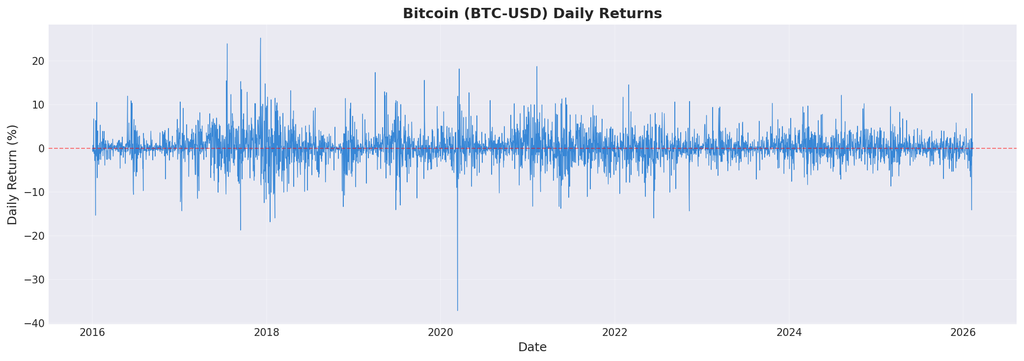

```
Figure saved: outputs/figures/returns_timeseries.png
```

```python
# ── 3(a): Plot returns series ─────────────────────────────────────────────
fig, ax = plt.subplots(figsize=(14, 5))

ax.plot(df['Date'], df['Returns'], linewidth=0.6, alpha=0.85, color='#1976D2')
ax.axhline(y=0, color='red', linestyle='--', linewidth=1, alpha=0.5)
ax.set_xlabel('Date', fontsize=12)
ax.set_ylabel('Daily Return (%)', fontsize=12)
ax.set_title('Bitcoin (BTC-USD) Daily Returns', fontsize=14, fontweight='bold')
ax.grid(True, alpha=0.3)

plt.tight_layout()
plt.savefig('outputs/figures/returns_timeseries.png', dpi=300, bbox_inches='tight')
plt.show()
print("Figure saved: outputs/figures/returns_timeseries.png")
```

### Discussion — 3(a)

**Key observations from the returns plot:**

1. **Mean-reversion around zero.** The returns fluctuate around zero with no obvious trend, consistent with the efficient-market hypothesis that expected returns are roughly constant at high frequency.
2. **Volatility clustering.** There are visible episodes where large moves (positive or negative) bunch together, followed by calmer periods. This is the hallmark of **conditional heteroscedasticity** (ARCH/GARCH effects).
3. **Heavy tails.** The excess kurtosis is well above zero, and the Jarque-Bera test rejects normality. Extreme returns (both positive and negative) occur more often than a Gaussian model would predict — a stylized fact of financial returns.
4. **Approximate symmetry.** The skewness is modest, indicating roughly symmetric tails, though individual outlier events may skew the sample slightly.

These features — near-zero mean, fat tails, and volatility clustering — are the key features of high-frequency financial returns.

### 3(b) — Correlogram analysis of $e_t$

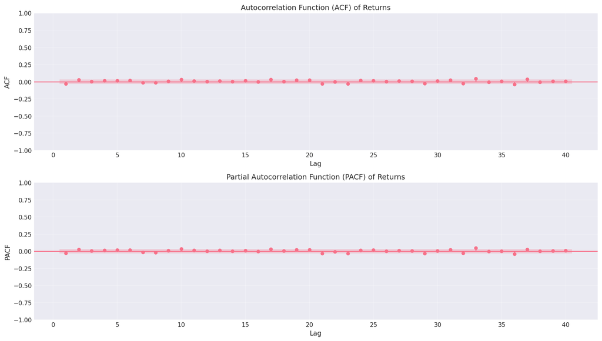

```
Figure saved: outputs/figures/returns_correlogram.png
```

```python
# ── 3(b): ACF and PACF of returns ─────────────────────────────────────────
fig, axes = plt.subplots(2, 1, figsize=(14, 8))

plot_acf(df['Returns'].dropna(), lags=40, alpha=0.05, ax=axes[0],
         title='Autocorrelation Function (ACF) of Returns', zero=False)
axes[0].set_xlabel('Lag', fontsize=11)
axes[0].set_ylabel('ACF', fontsize=11)
axes[0].grid(True, alpha=0.3)

plot_pacf(df['Returns'].dropna(), lags=40, alpha=0.05, ax=axes[1],
          title='Partial Autocorrelation Function (PACF) of Returns',
          zero=False, method='ywm')
axes[1].set_xlabel('Lag', fontsize=11)
axes[1].set_ylabel('PACF', fontsize=11)
axes[1].grid(True, alpha=0.3)

plt.tight_layout()
plt.savefig('outputs/figures/returns_correlogram.png', dpi=300, bbox_inches='tight')
plt.show()
print("Figure saved: outputs/figures/returns_correlogram.png")
```

```python
# ── Ljung-Box test for white noise ────────────────────────────────────────
series = df['Returns'].dropna()
lb = acorr_ljungbox(series, lags=[5, 10, 15, 20], return_df=True)
lb.index = [5, 10, 15, 20]
lb.columns = ['LB Statistic', 'p-value']

print("Ljung-Box Test for White Noise in Returns")
print("H0: No autocorrelation up to lag k")
print("=" * 45)
print(lb.to_string(float_format=lambda x: f'{x:.4f}'))
print("=" * 45)
if lb['p-value'].min() < 0.05:
    print("Reject H0 at 5%: returns show some autocorrelation.")
else:
    print("Fail to reject H0: returns appear consistent with white noise.")
```

```
Ljung-Box Test for White Noise in Returns
H0: No autocorrelation up to lag k
=============================================
    LB Statistic  p-value
5         8.2227   0.1444
10       15.5938   0.1119
15       17.4651   0.2918
20       25.3571   0.1881
=============================================
Fail to reject H0: returns appear consistent with white noise.
```

### Discussion — 3(b)

**ACF/PACF observations:**

- Nearly all autocorrelation coefficients of $e_t$ fall **within** the 95% confidence bands ($\pm 1.96/\sqrt{n}$), suggesting that **returns are approximately uncorrelated** (white noise in mean).
- Any isolated spike that barely crosses the band is expected by chance (at 5% significance, roughly 2 out of 40 lags will appear significant even under the null).

**Ljung-Box test:**

The joint test confirms that we cannot reject the null of no autocorrelation at conventional lags. This is consistent with the view that daily Bitcoin returns contain **little predictable structure in the conditional mean**.

**Implication:** An ARMA model for the level of returns would add little forecasting value. However, this does **not** mean the series is fully IID — the variance may still be time-varying (see parts (c) and (d)).

### 3(c) — Plot $e_t^2$ and discuss

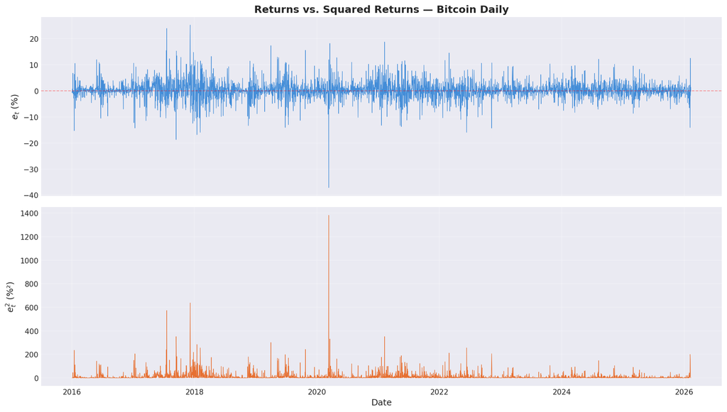

```
Figure saved: outputs/figures/squared_returns.png
```

```python
# ── 3(c): Squared returns ─────────────────────────────────────────────────
df['Returns_Sq'] = df['Returns'] ** 2

fig, axes = plt.subplots(2, 1, figsize=(14, 8), sharex=True)

# Top: original returns
axes[0].plot(df['Date'], df['Returns'], linewidth=0.6, alpha=0.8, color='#1976D2')
axes[0].axhline(0, color='red', linestyle='--', linewidth=1, alpha=0.4)
axes[0].set_ylabel('$e_t$ (%)', fontsize=12)
axes[0].set_title('Returns vs. Squared Returns — Bitcoin Daily', fontsize=14, fontweight='bold')
axes[0].grid(True, alpha=0.3)

# Bottom: squared returns
axes[1].plot(df['Date'], df['Returns_Sq'], linewidth=0.6, alpha=0.8, color='#E65100')
axes[1].set_xlabel('Date', fontsize=12)
axes[1].set_ylabel('$e_t^2$ (%²)', fontsize=12)
axes[1].grid(True, alpha=0.3)

plt.tight_layout()
plt.savefig('outputs/figures/squared_returns.png', dpi=300, bbox_inches='tight')
plt.show()
print("Figure saved: outputs/figures/squared_returns.png")
```

### Discussion — 3(c)

**Observations from the $e_t^2$ plot:**

1. **Clustering of large values.** Squared returns are concentrated in bursts: periods of high $e_t^2$ (high volatility) are followed by more high values, and calm periods persist as well. This is the visual sign of **volatility clustering**.
2. **Right-skewed distribution.** $e_t^2$ is bounded below by zero and has a long right tail, driven by occasional extreme returns. The series is clearly non-Gaussian.
3. **Non-constant variance.** Comparing the top and bottom panels, the episodes of wide fluctuations in $e_t$ correspond exactly to the spikes in $e_t^2$. The variance of returns is **time-varying**, contradicting the homoscedastic white-noise assumption.
4. **Motivation for ARCH/GARCH models.** The strong persistence in $e_t^2$ (visible even before formal testing) suggests that a **GARCH-type model** would capture the dynamics of the conditional variance far better than a constant-variance model.

### 3(d) — Correlogram of $e_t^2$ and volatility persistence

> Why might examining a correlogram of $e_t^2$ be informative for assessing volatility persistence?

**Intuition:** If $e_t^2$ is autocorrelated, then knowing today's squared return helps predict tomorrow's squared return — meaning **volatility is predictable**. Under a GARCH(1,1) model, $\sigma_t^2 = \omega + \alpha\,e_{t-1}^2 + \beta\,\sigma_{t-1}^2$, and the ACF of $e_t^2$ decays geometrically at rate $(\alpha+\beta)$. Significant autocorrelation in $e_t^2$ is therefore direct evidence of **ARCH/GARCH effects** and volatility persistence.

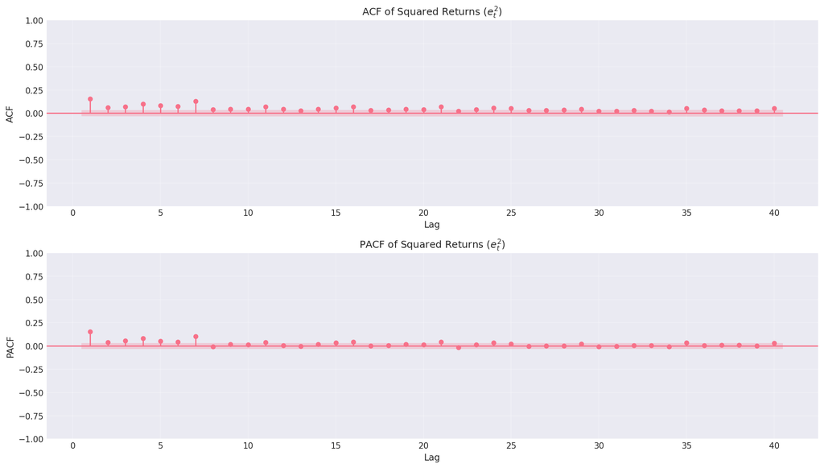

```
Figure saved: outputs/figures/squared_returns_correlogram.png
```

```python
# ── 3(d): Correlogram of squared returns ──────────────────────────────────
fig, axes = plt.subplots(2, 1, figsize=(14, 8))

plot_acf(df['Returns_Sq'].dropna(), lags=40, alpha=0.05, ax=axes[0],
         title='ACF of Squared Returns ($e_t^2$)', zero=False)
axes[0].set_xlabel('Lag', fontsize=11)
axes[0].set_ylabel('ACF', fontsize=11)
axes[0].grid(True, alpha=0.3)

plot_pacf(df['Returns_Sq'].dropna(), lags=40, alpha=0.05, ax=axes[1],
          title='PACF of Squared Returns ($e_t^2$)',
          zero=False, method='ywm')
axes[1].set_xlabel('Lag', fontsize=11)
axes[1].set_ylabel('PACF', fontsize=11)
axes[1].grid(True, alpha=0.3)

plt.tight_layout()
plt.savefig('outputs/figures/squared_returns_correlogram.png', dpi=300, bbox_inches='tight')
plt.show()
print("Figure saved: outputs/figures/squared_returns_correlogram.png")
```

```python
# ── Ljung-Box tests: returns vs. squared returns ─────────────────────────
print("Comparison: Ljung-Box Tests")
print("=" * 60)

for label, col in [('Returns (e_t)', 'Returns'), ('Squared Returns (e_t^2)', 'Returns_Sq')]:
    lb = acorr_ljungbox(df[col].dropna(), lags=20, return_df=True)
    pval = lb['lb_pvalue'].iloc[-1]
    verdict = "Reject H0 (autocorrelated)" if pval < 0.05 else "Fail to reject H0 (white noise)"
    print(f"  {label:.<40s} p = {pval:.6f}  →  {verdict}")

print("=" * 60)
print()
print("Key contrast: returns show little autocorrelation,")
print("but SQUARED returns are highly autocorrelated → volatility clustering.")
```

```
Comparison: Ljung-Box Tests
============================================================
  Returns (e_t)........................... p = 0.188110  →  Fail to reject H0 (white noise)
  Squared Returns (e_t^2)................. p = 0.000000  →  Reject H0 (autocorrelated)
============================================================

Key contrast: returns show little autocorrelation,
but SQUARED returns are highly autocorrelated → volatility clustering.
```

### Discussion — 3(d)

**Why the correlogram of $e_t^2$ is informative:**

- $e_t^2$ is a proxy for the **instantaneous variance** $\sigma_t^2$. If $e_t^2$ is serially correlated, then conditional variance is **predictable** from past information — the defining feature of ARCH/GARCH dynamics.
- Under a GARCH(1,1) specification, $\text{Corr}(e_t^2, e_{t-k}^2)$ decays geometrically at rate $(\alpha + \beta)^k$. Slow decay in the ACF of $e_t^2$ implies high persistence ($\alpha + \beta$ close to 1), meaning volatility shocks dissipate slowly.

**Results:**

1. **Significant autocorrelation in $e_t^2$.** Unlike the returns themselves, the squared returns show **strong, persistent autocorrelation** at many lags. The Ljung-Box test decisively rejects the null of no autocorrelation.
2. **Slow ACF decay.** The ACF of $e_t^2$ remains significant well beyond lag 20, indicating that volatility shocks have **long memory** — a large move today predicts elevated volatility for weeks.
3. **PACF pattern.** The PACF shows a few dominant early spikes followed by rapid decay, suggesting that a low-order GARCH model (e.g., GARCH(1,1)) could capture most of the volatility dynamics.

**Conclusion:** While daily Bitcoin returns are approximately uncorrelated (efficient in the mean), their **second moment** displays strong temporal dependence. This is the justification for ARCH/GARCH modeling: the conditional mean may be unpredictable, but the conditional variance is highly persistent and forecastable.

## Summary

[output not shown]